# Instagram & Weather Central Park:

### joining IG data with NOAA Quality-Controlled Local Climate Data for analysis

##### Damon Crockett, damoncrockett@gmail.com, for Software Studies Lab, Calit2, UCSD

```python
%matplotlib inline
import pandas as pd
import numpy as np
import matplotlib.pyplot as plt
from scipy.stats import *
import dateutil.parser
import datetime
```

```python
pd.set_option('display.max_rows', 1500)
pd.set_option('max_colwidth', 400)
```

### data import and cleaning

```python
instagram = pd.read_csv('/Users/damoncrockett/Dropbox/thinkpad_desktop_2/IGNOAA/insta_query_lat_lon.csv')
```

```python
instagram.columns
```

```
Index([u'link_author', u'link_enclosure', u'lat', u'lon', u'updated', u'date'], dtype='object')
```

```python
# grab relevant columns

instagram = instagram[['link_author','lat','lon', 'updated']]
```

```python
instagram.head()
```

|  | link_author | lat | lon | updated |
| --- | --- | --- | --- | --- |
| 0 | http://www.instagram.com/queen_yeezy | 40.8426 | -73.9143 | 2014-02-26 02:18:54 |
| 1 | http://www.instagram.com/la_balby | 40.8617 | -73.9103 | 2014-02-26 02:18:58 |
| 2 | http://www.instagram.com/shainflocka | 40.8301 | -73.9198 | 2014-02-26 02:19:57 |
| 3 | http://www.instagram.com/ashleybohan_ | 40.8635 | -73.9254 | 2014-02-26 02:20:48 |
| 4 | http://www.instagram.com/marleyhour101_ | 40.8373 | -73.9442 | 2014-02-26 02:21:02 |

We have our instagram data. We'll set that aside for now and focus on the weather.

### NOAA weather data

```python
# previously cleaned weather data from NOAA, 'Quality-Controlled Local Climate Data', February through August, 2014

weather = pd.read_csv('/Users/damoncrockett/Dropbox/thinkpad_desktop_2/IGNOAA/manhattan_weather_2014_FEBthruAUG.csv')
```

```python
weather.head()
```

|  | station | date | time | sky | temp | wind | precipitation |
| --- | --- | --- | --- | --- | --- | --- | --- |
| 0 | CENTRAL PARK | 20140701 | 51 | CLR | 75 | 7 |  |
| 1 | CENTRAL PARK | 20140701 | 151 | CLR | 74 | 8 |  |
| 2 | CENTRAL PARK | 20140701 | 251 | CLR | 73 | 3 |  |
| 3 | CENTRAL PARK | 20140701 | 351 | CLR | 73 | 6 |  |
| 4 | CENTRAL PARK | 20140701 | 451 | CLR | 72 | 0 |  |

```python
# we want the only Manhattan data we have, Central Park, and we want a slightly smaller date range to match the IG data

weather = weather[weather.station == 'CENTRAL PARK']
del weather['station']
weather = weather[weather.date > 20140224]
weather = weather[weather.date < 20140804]
```

```python
weather.head()
```

|  | date | time | sky | temp | wind | precipitation |
| --- | --- | --- | --- | --- | --- | --- |
| 0 | 20140701 | 51 | CLR | 75 | 7 |  |
| 1 | 20140701 | 151 | CLR | 74 | 8 |  |
| 2 | 20140701 | 251 | CLR | 73 | 3 |  |
| 3 | 20140701 | 351 | CLR | 73 | 6 |  |
| 4 | 20140701 | 451 | CLR | 72 | 0 |  |

Okay we need to make date and time into strings, zero fill the times to 4 digits, combine the strings, and then run a datetime operation on them. Easy peasy in python:

```python
# make datetime objects

weather['date'] = weather.date.map(lambda x: str(x))
weather['time'] = weather.time.map(lambda x: str(x))
weather['time'] = weather.time.map(lambda x: x.zfill(4))

# we call these 'resolution' because we will resolve to these datetime values
weather['resolution'] = weather.date + weather.time
weather['resolution'] = weather.resolution.map(lambda x: datetime.datetime.strptime(x, '%Y%m%d%H%M'))
```

```python
weather.head()
```

|  | date | time | sky | temp | wind | precipitation | resolution |
| --- | --- | --- | --- | --- | --- | --- | --- |
| 0 | 20140701 | 0051 | CLR | 75 | 7 |  | 2014-07-01 00:51:00 |
| 1 | 20140701 | 0151 | CLR | 74 | 8 |  | 2014-07-01 01:51:00 |
| 2 | 20140701 | 0251 | CLR | 73 | 3 |  | 2014-07-01 02:51:00 |
| 3 | 20140701 | 0351 | CLR | 73 | 6 |  | 2014-07-01 03:51:00 |
| 4 | 20140701 | 0451 | CLR | 72 | 0 |  | 2014-07-01 04:51:00 |

Great. Now we can delete the original columns.

```python
del weather['date']
del weather['time']
```

```python
weather.tail()
```

|  | sky | temp | wind | precipitation | resolution |
| --- | --- | --- | --- | --- | --- |
| 6432 | CLR | 76 | 0 |  | 2014-06-30 19:51:00 |
| 6433 | CLR | 76 | 3 |  | 2014-06-30 20:51:00 |
| 6434 | CLR | 75 | 5 |  | 2014-06-30 21:51:00 |
| 6435 | CLR | 76 | 5 |  | 2014-06-30 22:51:00 |
| 6436 | CLR | 75 | 5 |  | 2014-06-30 23:51:00 |

```python
# reset index because we will be breaking out some values and then bringing them in later, and we want to keep our indices straight

weather = weather.reset_index(drop=True)
```

## sky variable

Our sky variable has linear information (both in fraction of sky covered and height of cloud layer(s)), and we should preserve at least some of it, as we should expect that some linear relationship exists between the fraction of sky covered and what the sky looks like, at least.

```python
# sky is reported in layers, min = 1 and max = 3; break those out

sky = pd.DataFrame(weather.sky.str.split(' ',2).tolist(),
                       columns = ['sky1','sky2','sky3'])
```

```python
sky.head(15)
```

|  | sky1 | sky2 | sky3 |
| --- | --- | --- | --- |
| 0 | CLR | None | None |
| 1 | CLR | None | None |
| 2 | CLR | None | None |
| 3 | CLR | None | None |
| 4 | CLR | None | None |
| 5 | CLR | None | None |
| 6 | BKN070 | None | None |
| 7 | CLR | None | None |
| 8 | CLR | None | None |
| 9 | CLR | None | None |
| 10 | FEW033 | None | None |
| 11 | FEW036 | None | None |
| 12 | FEW041 | SCT050 | BKN070 |
| 13 | BKN065 | BKN080 | None |
| 14 | FEW055 | None | None |

```python
del weather['sky']
```

```python
# add results of split back to the weather df

weather['sky1'] = sky.sky1
weather['sky2'] = sky.sky2
weather['sky3'] = sky.sky3
```

```python
# make sure all weather values are strings

weather.sky1 = weather.sky1.map(lambda x: str(x))
weather.sky2 = weather.sky2.map(lambda x: str(x))
weather.sky3 = weather.sky3.map(lambda x: str(x))
```

```python
# remove all missing data labeled 'M'

weather = weather[~weather.sky1.str.contains('M')]
weather = weather[~weather.sky2.str.contains('M')]
weather = weather[~weather.sky3.str.contains('M')]
```

```python
# reset index again

weather = weather.reset_index(drop=True)
```

```python
"""
From our sky columns (the result of the sky variable split),
make 3 new dataframes, one for each column, which we will
use to compute final sky-cover values; use regex to separate
words from numbers.

"""

import re
sky1 = pd.DataFrame(weather.sky1.map(lambda x: re.findall(r"[^\W\d_]+|\d+", x)).tolist(),
                       columns = ['condition','height'])
sky2 = pd.DataFrame(weather.sky2.map(lambda x: re.findall(r"[^\W\d_]+|\d+", x)).tolist(),
                       columns = ['condition','height'])
sky3 = pd.DataFrame(weather.sky3.map(lambda x: re.findall(r"[^\W\d_]+|\d+", x)).tolist(),
                       columns = ['condition','height'])
```

Okay, now we have all the information split up so we can explore it. We don't know exactly yet what to keep, or how to model the sky cover, but let's take a look:

```python
sky1.head(15)
```

|  | condition | height |
| --- | --- | --- |
| 0 | CLR | None |
| 1 | CLR | None |
| 2 | CLR | None |
| 3 | CLR | None |
| 4 | CLR | None |
| 5 | CLR | None |
| 6 | BKN | 070 |
| 7 | CLR | None |
| 8 | CLR | None |
| 9 | CLR | None |
| 10 | FEW | 033 |
| 11 | FEW | 036 |
| 12 | FEW | 041 |
| 13 | BKN | 065 |
| 14 | FEW | 055 |

Let's see what types of sky cover are most common in Central Park:

```python
sky1.condition.value_counts()
```

```
CLR    1932
OVC    1159
BKN     693
FEW     594
SCT     446
VV        8
dtype: int64
```

```python
sky2.condition.value_counts()
```

```
None    3785
BKN      469
OVC      404
SCT      149
FEW       25
dtype: int64
```

```python
sky3.condition.value_counts()
```

```
None    4405
OVC      311
BKN      104
SCT       12
dtype: int64
```

#### NOAA handbook

http://www.nws.noaa.gov/om/forms/resources/SFCTraining.pdf

According to the NOAA training handbook for weather observers, sky cover is determined as follows (briefly):

The cloud cover is split into layers, with a max of three. It is then determined how much of the sky is covered in the first layer. The measurement of cloud cover at the second and third layers is a cumulative. That's good for us, because all we want to know is how much of the sky is covered. Layers are given heights in hundreds of feet, but we won't bother with that information, since it's not clear how we'd use it to measure anything affecting people on the ground.

## The Sky Variable

So, our computation is simple: give fractions for sky cover codes, per the NOAA definitions. Then find the cumulative max for each observation. That fraction will be our sky value.

```python
# change condition codes to fractions of sky cover per definitions in NOAA doc

d = {'CLR': 0,
     'FEW': 0.1875,
     'SCT': 0.4375,
     'BKN': 0.75,
     'OVC': 1,
     'VV': 1,
     'None': 0}

sky1['condition'].replace(d, inplace=True)
sky2['condition'].replace(d, inplace=True)
sky3['condition'].replace(d, inplace=True)
```

```python
# add to weather df make sure everything is float

weather['sky1'] = sky1.condition
weather['sky2'] = sky2.condition
weather['sky3'] = sky3.condition

weather['sky1'] = weather.sky1.map(lambda x: float(x))
weather['sky2'] = weather.sky2.map(lambda x: float(x))
weather['sky3'] = weather.sky3.map(lambda x: float(x))
```

```python
# find max across the 3 columns for each observation

weather['sky'] = weather[['sky1','sky2','sky3']].max(axis=1)
```

```python
weather.head(15)
```

|  | temp | wind | precipitation | resolution | sky1 | sky2 | sky3 | sky |
| --- | --- | --- | --- | --- | --- | --- | --- | --- |
| 0 | 75 | 7 |  | 2014-07-01 00:51:00 | 0.0000 | 0.0000 | 0.00 | 0.0000 |
| 1 | 74 | 8 |  | 2014-07-01 01:51:00 | 0.0000 | 0.0000 | 0.00 | 0.0000 |
| 2 | 73 | 3 |  | 2014-07-01 02:51:00 | 0.0000 | 0.0000 | 0.00 | 0.0000 |
| 3 | 73 | 6 |  | 2014-07-01 03:51:00 | 0.0000 | 0.0000 | 0.00 | 0.0000 |
| 4 | 72 | 0 |  | 2014-07-01 04:51:00 | 0.0000 | 0.0000 | 0.00 | 0.0000 |
| 5 | 74 | M |  | 2014-07-01 05:51:00 | 0.0000 | 0.0000 | 0.00 | 0.0000 |
| 6 | 75 | M |  | 2014-07-01 06:51:00 | 0.7500 | 0.0000 | 0.00 | 0.7500 |
| 7 | 76 | M |  | 2014-07-01 07:51:00 | 0.0000 | 0.0000 | 0.00 | 0.0000 |
| 8 | 79 | 0 |  | 2014-07-01 08:51:00 | 0.0000 | 0.0000 | 0.00 | 0.0000 |
| 9 | 82 | 3 |  | 2014-07-01 09:51:00 | 0.0000 | 0.0000 | 0.00 | 0.0000 |
| 10 | 86 | 5 |  | 2014-07-01 10:51:00 | 0.1875 | 0.0000 | 0.00 | 0.1875 |
| 11 | 87 | 6 |  | 2014-07-01 11:51:00 | 0.1875 | 0.0000 | 0.00 | 0.1875 |
| 12 | 88 | 7 |  | 2014-07-01 12:51:00 | 0.1875 | 0.4375 | 0.75 | 0.7500 |
| 13 | 85 | 6 |  | 2014-07-01 13:51:00 | 0.7500 | 0.7500 | 0.00 | 0.7500 |
| 14 | 86 | 6 |  | 2014-07-01 14:51:00 | 0.1875 | 0.0000 | 0.00 | 0.1875 |

```python
# remove individual sky columns

del weather['sky1']
del weather['sky2']
del weather['sky3']
```

```python
weather.head()
```

|  | temp | wind | precipitation | resolution | sky |
| --- | --- | --- | --- | --- | --- |
| 0 | 75 | 7 |  | 2014-07-01 00:51:00 | 0 |
| 1 | 74 | 8 |  | 2014-07-01 01:51:00 | 0 |
| 2 | 73 | 3 |  | 2014-07-01 02:51:00 | 0 |
| 3 | 73 | 6 |  | 2014-07-01 03:51:00 | 0 |
| 4 | 72 | 0 |  | 2014-07-01 04:51:00 | 0 |

#### Voila! We have a sky variable.

## aggregating by time

Now we can aggregate our weather results by datetime. We will then make the difficult join on datetime.

```python
# clean up wind variable

weather = weather[weather.wind != 'M']
```

```python
# clean up precipitation variable

d = {" ": 0,
     "T": 0.001,
     "  T": 0.001}

weather['precipitation'].replace(d, inplace=True)
```

```python
# reset index once more

weather = weather.reset_index(drop=True)
```

```python
# make sure everything a float once again

weather.temp = weather.temp.map(lambda x: float(x))
weather.wind = weather.wind.map(lambda x: float(x))
weather.precipitation = weather.precipitation.map(lambda x: float(x))
weather.sky = weather.sky.map(lambda x: float(x))
```

```python
# Finally we have a clean dataframe!

weather.head(15)
```

|  | temp | wind | precipitation | resolution | sky |
| --- | --- | --- | --- | --- | --- |
| 0 | 75 | 7 | 0 | 2014-07-01 00:51:00 | 0.0000 |
| 1 | 74 | 8 | 0 | 2014-07-01 01:51:00 | 0.0000 |
| 2 | 73 | 3 | 0 | 2014-07-01 02:51:00 | 0.0000 |
| 3 | 73 | 6 | 0 | 2014-07-01 03:51:00 | 0.0000 |
| 4 | 72 | 0 | 0 | 2014-07-01 04:51:00 | 0.0000 |
| 5 | 79 | 0 | 0 | 2014-07-01 08:51:00 | 0.0000 |
| 6 | 82 | 3 | 0 | 2014-07-01 09:51:00 | 0.0000 |
| 7 | 86 | 5 | 0 | 2014-07-01 10:51:00 | 0.1875 |
| 8 | 87 | 6 | 0 | 2014-07-01 11:51:00 | 0.1875 |
| 9 | 88 | 7 | 0 | 2014-07-01 12:51:00 | 0.7500 |
| 10 | 85 | 6 | 0 | 2014-07-01 13:51:00 | 0.7500 |
| 11 | 86 | 6 | 0 | 2014-07-01 14:51:00 | 0.1875 |
| 12 | 84 | 5 | 0 | 2014-07-01 15:51:00 | 0.7500 |
| 13 | 85 | 5 | 0 | 2014-07-01 16:51:00 | 0.1875 |
| 14 | 84 | 5 | 0 | 2014-07-01 17:51:00 | 0.7500 |

#### some histograms

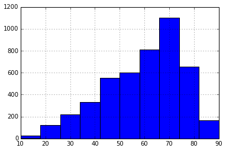

```python
weather.temp.hist()
```

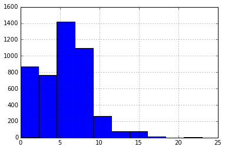

```python
weather.wind.hist()
```

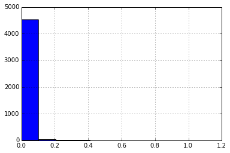

```python
weather.precipitation.hist()
```

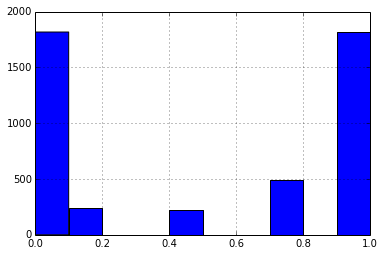

```python
weather.sky.hist()
```

```python
# check to see whether all datetimes are unique; if so, we don't need to aggregate

print len(weather.index), len(weather.resolution.unique())
```

```
4591 4591
```

Ok, well here's the place we would aggregate the data using 'pd.df.groupby', grouping by day, perhaps. We won't do it here, because we are going to join this weather data on IG datetime data that is even finer-grained, and we don't want to lose any grain. And in any case, we will add in some datetime variables (like hour, month, weekday) that will enable us to look at aggregated means anyway.

## joining weather and instagram data

We can join on times, of course, and we will, but first, we need to reduce the instagram dataset, for two reasons. The first is just that it's too big to load into R, where we want to do our real analysis. Second, and more importantly perhaps, the weather readings are all from a single weather station in Central Park, but the Instagram records are from all over NYC. Let's map our Instagram points in grey and our target area in a yellow box, centered on Central Park:

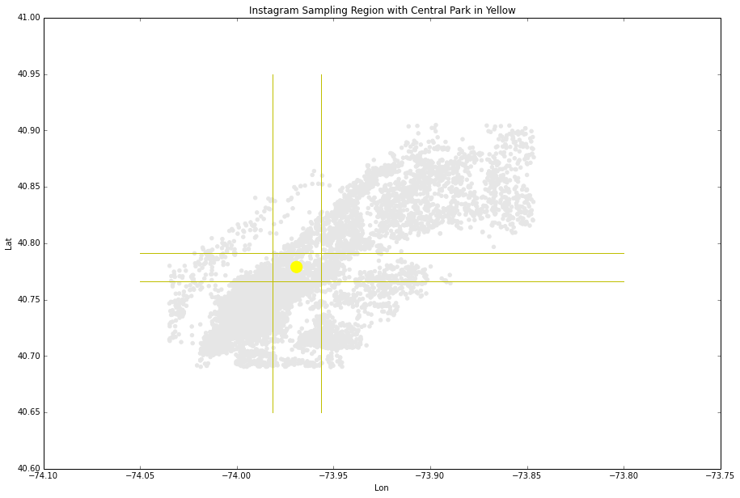

```python
instagram_sample = instagram.ix[np.random.choice(instagram.index.values, 10000)]

x = instagram_sample.lon
y = instagram_sample.lat

# Central Park weather station coordinates
x2 = -73.96917
y2 = 40.77889

fig, ax = plt.subplots(figsize=(15,10))

ax.scatter(x, y, color='0.9')
ax.scatter(x2, y2, s=200, color='yellow')

plt.xlabel('Lon')
plt.ylabel('Lat')
plt.title('Instagram Sampling Region with Central Park in Yellow')


MARGIN = 0.0125

plt.plot([x2 + MARGIN, x2 + MARGIN],[40.65, 40.95],'y')
plt.plot([x2 - MARGIN, x2 - MARGIN],[40.65, 40.95],'y')
plt.plot([-74.05, -73.80],[y2 + MARGIN, y2 + MARGIN],'y')
plt.plot([-74.05, -73.80],[y2 - MARGIN, y2 - MARGIN],'y')
```

Just for fun, let's look at that same region laid over a density map of Instagram records.

[figure not shown]

```python
instagram_sample = instagram.ix[np.random.choice(instagram.index.values, 10000)]

x = instagram_sample.lon
y = instagram_sample.lat

# Central Park weather station coordinates
x2 = -73.96917
y2 = 40.77889

xy = np.vstack([x,y])
z = gaussian_kde(xy)(xy)
fig, ax = plt.subplots(figsize=(15,10))

ax.scatter(x, y, c=z, s=20, edgecolor='')
ax.scatter(x2, y2, s=200, color='yellow')

plt.xlabel('Lon')
plt.ylabel('Lat')
plt.title('Instagram Sampling Region with Central Park in Yellow, Laid over Density Map')


MARGIN = 0.0125

plt.plot([x2 + MARGIN, x2 + MARGIN],[40.65, 40.95],'y')
plt.plot([x2 - MARGIN, x2 - MARGIN],[40.65, 40.95],'y')
plt.plot([-74.05, -73.80],[y2 + MARGIN, y2 + MARGIN],'y')
plt.plot([-74.05, -73.80],[y2 - MARGIN, y2 - MARGIN],'y')
```

Okay, now let's cut our instagram dataset to just these points, and then plot them to make sure we got it right.

```python
x2 = -73.96917
y2 = 40.77889
MARGIN = 0.0125

instagram = instagram[instagram.lat > (y2 - MARGIN)]
instagram = instagram[instagram.lat < (y2 + MARGIN)]
instagram = instagram[instagram.lon > (x2 - MARGIN)]
instagram = instagram[instagram.lon < (x2 + MARGIN)]
```

```python
# reset index

instagram = instagram.reset_index(drop=True)
```

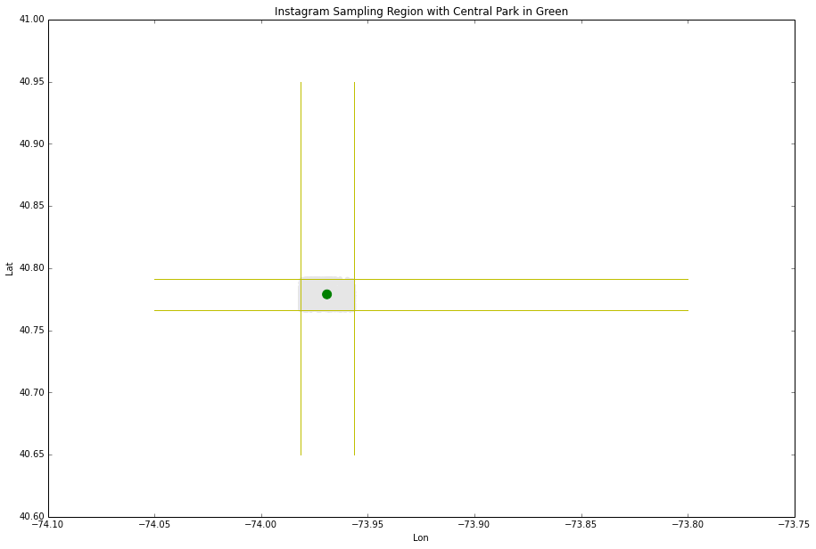

```python
instagram_sample = instagram.ix[np.random.choice(instagram.index.values, 10000)]

x = instagram_sample.lon
y = instagram_sample.lat


# Central Park coordinates
x2 = -73.96917
y2 = 40.77889

fig, ax = plt.subplots(figsize=(15,10))

ax.scatter(x, y, s=20, color='0.9')
ax.scatter(x2, y2, s=100, color='green')

plt.xlabel('Lon')
plt.ylabel('Lat')
plt.title('Instagram Sampling Region with Central Park in Green')

MARGIN = 0.0125

plt.plot([x2 + MARGIN, x2 + MARGIN],[40.65, 40.95],'y')
plt.plot([x2 - MARGIN, x2 - MARGIN],[40.65, 40.95],'y')
plt.plot([-74.05, -73.80],[y2 + MARGIN, y2 + MARGIN],'y')
plt.plot([-74.05, -73.80],[y2 - MARGIN, y2 - MARGIN],'y')
```

```python
len(instagram.index)
```

```
538151
```

We've got a good number of records here, but not enough to overload R. Perfect.

### Instagram datetimes

Now there are two additional things we need to do before we get the join started. First, we need simply to parse the Instagram 'updated' column using Python's dateutil module so that we can harness the power of Python's datetime object. Then, we need to adjust the IG datetimes because they actually don't measure local time! This is an important lesson about data science - something as simple as a timezone mismatch could really throw off your analysis!

```python
instagram.updated = instagram.updated.apply(dateutil.parser.parse)
```

```python
# IG datetimes are GMT and we need NYC time, so we need to subtract 4 hours

instagram.updated = instagram.updated - datetime.timedelta(hours=4)
```

### the join

Okay. Now that we have both our weather and IG records with datetimes, we need to join on those datetimes. But we can't do a join yet, because the two datetimes don't match very well: the IG datetimes are organically-generated and all over the place. The weather datetimes are at regular observation intervals. What we want to know, for any given IG datetime, is the closest weather datetime. In order to find that, we will iterate through all the IG datetimes, subtracting every weather datetime (within a small range) from each and finding the minimum difference. Whatever weather datetime we subtracted to produce the minimum, that will be assigned the IG datetime.

```python
# the major operation

resolution = []

for item in instagram.updated:

    # make tmp series with only those timestamps within a certain range

    margin = datetime.timedelta(hours=1)
    tmp = weather.resolution[[item - margin <= member <= item + margin for member in weather.resolution]]

    # crucial step: find the closest weather datetime; the 'key' argument for min() makes this pretty easy
    if len(tmp) == 0:
        resolution.append('nan')
    else:
        a = min(tmp, key = lambda x: abs(item - x))
        resolution.append(a)

instagram['resolution'] = resolution
```

```python
instagram.head()
```

|  | link_author | lat | lon | updated | resolution |
| --- | --- | --- | --- | --- | --- |
| 0 | http://www.instagram.com/alkemiemama | 40.7725 | -73.9587 | 2014-02-25 23:09:14 | 2014-02-25 22:51:00 |
| 1 | http://www.instagram.com/yoooonsun | 40.7798 | -73.9633 | 2014-02-25 23:09:38 | 2014-02-25 22:51:00 |
| 2 | http://www.instagram.com/lindaguaizi | 40.7748 | -73.9632 | 2014-02-25 23:11:29 | 2014-02-25 22:51:00 |
| 3 | http://www.instagram.com/isabellabuonomo | 40.7747 | -73.9574 | 2014-02-25 23:11:47 | 2014-02-25 22:51:00 |
| 4 | http://www.instagram.com/letisyaoymakas | 40.7739 | -73.9711 | 2014-02-25 23:13:06 | 2014-02-25 22:51:00 |

```python
instagram.to_csv('/Users/damoncrockett/Dropbox/thinkpad_desktop_2/IGNOAA/instagram_resolved.csv')
```

```python
len(instagram.resolution[instagram.resolution.isnull()])
```

```
10146
```

#### resolution error

```python
# timedelta between actual and resolved time

instagram['error'] = abs(instagram.resolution - instagram.updated)
```

```python
instagram.error.max()
```

```
Timedelta('0 days 01:00:00')
```

Okay, this is what we should expect. We began our fuzzy join by selecting a range of weather records within an hour of each instagram post, and so our highest degree of resolution error should be one hour. I'm a little surprised that it's exactly one hour, but there you go.

```python
del instagram['error']
```

```python
instagram = instagram[instagram.resolution.notnull()]
```

```python
instagram.reset_index(drop=True,inplace=True)
```

```python
weather = weather.set_index(['resolution'])
```

```python
# the big join!

instagram = instagram.join(weather, on = 'resolution')
instagram.head()
```

|  | link_author | lat | lon | updated | resolution | temp | wind | precipitation | sky |
| --- | --- | --- | --- | --- | --- | --- | --- | --- | --- |
| 0 | http://www.instagram.com/alkemiemama | 40.7725 | -73.9587 | 2014-02-25 23:09:14 | 2014-02-25 22:51:00 | 27 | 3 | 0 | 0 |
| 1 | http://www.instagram.com/yoooonsun | 40.7798 | -73.9633 | 2014-02-25 23:09:38 | 2014-02-25 22:51:00 | 27 | 3 | 0 | 0 |
| 2 | http://www.instagram.com/lindaguaizi | 40.7748 | -73.9632 | 2014-02-25 23:11:29 | 2014-02-25 22:51:00 | 27 | 3 | 0 | 0 |
| 3 | http://www.instagram.com/isabellabuonomo | 40.7747 | -73.9574 | 2014-02-25 23:11:47 | 2014-02-25 22:51:00 | 27 | 3 | 0 | 0 |
| 4 | http://www.instagram.com/letisyaoymakas | 40.7739 | -73.9711 | 2014-02-25 23:13:06 | 2014-02-25 22:51:00 | 27 | 3 | 0 | 0 |

Before we finish up here, and send the data to R for analysis, let's make some additional time columns that will allow us easily to group by things like month, weekday, hour, etc.

```python
instagram['date'] = instagram.resolution.apply(datetime.datetime.date)
```

```python
instagram['weekday'] = instagram.date.apply(datetime.date.isoweekday)
```

```python
instagram['month'] = instagram.date.map(lambda x: x.month)
```

```python
instagram['hour'] = instagram.resolution.map(lambda x: x.hour)
```

```python
instagram.columns
```

```
Index([u'link_author', u'lat', u'lon', u'updated', u'resolution', u'temp', u'wind', u'precipitation', u'sky', u'date', u'weekday', u'month', u'hour'], dtype='object')
```

```python
# this is the full file

instagram.to_csv('/Users/damoncrockett/Dropbox/thinkpad_desktop_2/IGNOAA/instagram_weather.csv', encoding = 'utf-8')
```

Okay, we've sent off the full file. Now let's make a truncated dataset grouped by resolution time. We can eliminate any variables that cut more finely than the resolution. So, the actual latitude and longitude and the 'updated' column, as well as the 'linkauthor' column, can go.

```python
instagram_by_resolution = instagram[['resolution','temp','wind','precipitation','sky','date','weekday','month','hour']]
```

```python
# now we need to group instagram df by datetime

tmp = instagram_by_resolution.groupby('resolution')
instagram_by_resolution = tmp.agg(np.mean)
instagram_by_resolution['count'] = tmp.size()
instagram_by_resolution.head()
```

| resolution | temp | wind | precipitation | sky | weekday | month | hour | count |
| --- | --- | --- | --- | --- | --- | --- | --- | --- |
| 2014-02-25 22:51:00 | 27 | 3 | 0 | 0 | 2 | 2 | 22 | 11 |
| 2014-02-25 23:51:00 | 27 | 3 | 0 | 0 | 2 | 2 | 23 | 58 |
| 2014-02-26 00:51:00 | 26 | 0 | 0 | 0 | 3 | 2 | 0 | 46 |
| 2014-02-26 01:51:00 | 26 | 0 | 0 | 0 | 3 | 2 | 1 | 49 |
| 2014-02-26 02:51:00 | 27 | 0 | 0 | 0 | 3 | 2 | 2 | 18 |

Okay, we lost 'date' during groupby, probably because we cannot take the 'mean' of a date.

```python
# add date back in
instagram_by_resolution['resolution'] = instagram_by_resolution.index
instagram_by_resolution['date'] = instagram_by_resolution.resolution.apply(datetime.datetime.date)
del instagram_by_resolution['resolution']
```

```python
instagram_by_resolution.head()
```

| resolution | temp | wind | precipitation | sky | weekday | month | hour | count | date |
| --- | --- | --- | --- | --- | --- | --- | --- | --- | --- |
| 2014-02-25 22:51:00 | 27 | 3 | 0 | 0 | 2 | 2 | 22 | 11 | 2014-02-25 |
| 2014-02-25 23:51:00 | 27 | 3 | 0 | 0 | 2 | 2 | 23 | 58 | 2014-02-25 |
| 2014-02-26 00:51:00 | 26 | 0 | 0 | 0 | 3 | 2 | 0 | 46 | 2014-02-26 |
| 2014-02-26 01:51:00 | 26 | 0 | 0 | 0 | 3 | 2 | 1 | 49 | 2014-02-26 |
| 2014-02-26 02:51:00 | 27 | 0 | 0 | 0 | 3 | 2 | 2 | 18 | 2014-02-26 |

```python
len(instagram_by_resolution.index)
```

```
4488
```

```python
# send the final df to csv

instagram_by_resolution.to_csv('/Users/damoncrockett/Dropbox/thinkpad_desktop_2/IGNOAA/instagram_by_resolution.csv')
```